# Ações Vale

Renan Almeida

## **Configurando Ambiente e Importando os Dados**

Algumas bibiliotecas sao necessarias para a execucao e visualizacao grafica das analises realizadas nesse documento sobre dados da bolsa brasileira.

- BatchGetSymbols
- rugarch
- tidyverse
- ggthemes
- FinTS
- WriteXLS
- xtable
- tbl2xts

```r
library(BatchGetSymbols)
library(rugarch)
library(tidyverse)
library(ggthemes)
library(FinTS)
library(WriteXLS)
library(xtable)
library(tbl2xts)
```

Importamos as ações da Vale e armazenamos os log_retornos que serão utilizados no decorrer do desenvolvimento da atividade.

```r
tickers = c('VALE3.SA')

assets <- BatchGetSymbols(tickers,
                          first.date = '2019-01-01',
                          last.date = Sys.time(),
                          type.return = "log",
                          freq.data = "daily")
```

```
##
## Running BatchGetSymbols for:
##    tickers =VALE3.SA
## ^GSPC | yahoo (1|1) | Not Cached | Saving cache
## VALE3.SA | yahoo (1|1) | Not Cached | Saving cache - Got 96% of valid prices | Nice!
```

```r
assets <- assets[[2]]

log_retornos <- na.omit(assets$ret.adjusted.prices)
```

## **Modelo GARCH(1,1)**

Ajustamos um modelo GARCH(1,1) utilizando ambas as distribuições normal e t-student, respectivamente.

```r
spec_arch_norm <- ugarchspec(variance.model = list(model = "sGARCH", garchOrder = c(1, 1)),
                             mean.model = list(armaOrder = c(0, 0), include.mean = TRUE),
                             distribution.model = "norm")
fit_arch_norm <- ugarchfit(spec = spec_arch_norm, data = log_retornos)
print(fit_arch_norm)
```

```
##
## *---------------------------------*
## *          GARCH Model Fit        *
## *---------------------------------*
##
## Conditional Variance Dynamics
## -----------------------------------
## GARCH Model  : sGARCH(1,1)
## Mean Model   : ARFIMA(0,0,0)
## Distribution : norm
##
## Optimal Parameters
## ------------------------------------
##         Estimate  Std. Error   t value Pr(>|t|)
## mu      0.000113     4.9e-04   0.23028  0.81787
## omega   0.000009     1.0e-06   8.60989  0.00000
## alpha1  0.049861     4.1e-03  12.16065  0.00000
## beta1   0.931708     6.0e-03 155.27764  0.00000
##
## Robust Standard Errors:
##         Estimate  Std. Error  t value Pr(>|t|)
## mu      0.000113    0.000633  0.17819 0.858575
## omega   0.000009    0.000003  3.03787 0.002383
## alpha1  0.049861    0.012531  3.97887 0.000069
## beta1   0.931708    0.017649 52.79169 0.000000
##
## LogLikelihood : 3945.619
##
## Information Criteria
## ------------------------------------
##
## Akaike       -4.8542
## Bayes        -4.8409
## Shibata      -4.8542
## Hannan-Quinn -4.8493
##
## Weighted Ljung-Box Test on Standardized Residuals
## ------------------------------------
##                         statistic p-value
## Lag[1]                     0.6870  0.4072
```

[output cut: 37 more lines]

```
## Negative Sign Bias  1.9265 0.05422   *
## Positive Sign Bias  0.5536 0.57996
## Joint Effect        4.0900 0.25191
##
##
## Adjusted Pearson Goodness-of-Fit Test:
## ------------------------------------
##   group statistic p-value(g-1)
## 1    20     83.39    4.811e-10
## 2    30     90.54    3.001e-08
## 3    40    106.00    4.158e-08
## 4    50    111.04    1.030e-06
##
##
## Elapsed time : 0.143827
```

```r
spec_arch_t <- ugarchspec(variance.model = list(model = "sGARCH", garchOrder = c(1, 1)),
                          mean.model = list(armaOrder = c(0, 0), include.mean = TRUE),
                          distribution.model = "std")

fit_arch_t <- ugarchfit(spec = spec_arch_t, data = log_retornos)
print(fit_arch_t)
```

```
##
## *---------------------------------*
## *          GARCH Model Fit        *
## *---------------------------------*
##
## Conditional Variance Dynamics
## -----------------------------------
## GARCH Model  : sGARCH(1,1)
## Mean Model   : ARFIMA(0,0,0)
## Distribution : std
##
## Optimal Parameters
## ------------------------------------
##         Estimate  Std. Error  t value Pr(>|t|)
## mu      0.000118    0.000433  0.27239 0.785323
## omega   0.000028    0.000011  2.57549 0.010010
## alpha1  0.095506    0.024643  3.87556 0.000106
## beta1   0.847599    0.039938 21.22312 0.000000
## shape   4.743911    0.572276  8.28955 0.000000
##
## Robust Standard Errors:
##         Estimate  Std. Error  t value Pr(>|t|)
## mu      0.000118    0.000444  0.26561 0.790540
## omega   0.000028    0.000017  1.59608 0.110472
## alpha1  0.095506    0.038477  2.48218 0.013058
## beta1   0.847599    0.066699 12.70773 0.000000
## shape   4.743911    0.664509  7.13898 0.000000
##
## LogLikelihood : 4080.001
##
## Information Criteria
## ------------------------------------
##
## Akaike       -5.0185
## Bayes        -5.0019
## Shibata      -5.0185
## Hannan-Quinn -5.0123
##
## Weighted Ljung-Box Test on Standardized Residuals
## ------------------------------------
```

[output cut: 40 more lines]

```
## Negative Sign Bias  0.9467 0.3439
## Positive Sign Bias  0.7564 0.4495
## Joint Effect        1.7636 0.6229
##
##
## Adjusted Pearson Goodness-of-Fit Test:
## ------------------------------------
##   group statistic p-value(g-1)
## 1    20     21.15       0.3287
## 2    30     33.02       0.2769
## 3    40     47.18       0.1729
## 4    50     51.25       0.3856
##
##
## Elapsed time : 0.235172
```

## **Modelo EGARCH(1,1)**

Ajustamos um modelo EGARCH(1,1) utilizando ambas as distribuições normal e t-student, respectivamente.

```r
spec_egarch_norm <- ugarchspec(variance.model = list(model = "eGARCH", garchOrder = c(1, 1)),
                             mean.model = list(armaOrder = c(0, 0), include.mean = TRUE),
                             distribution.model = "norm")
fit_egarch_norm <- ugarchfit(spec = spec_egarch_norm, data = log_retornos)
print(fit_egarch_norm)
```

```
##
## *---------------------------------*
## *          GARCH Model Fit        *
## *---------------------------------*
##
## Conditional Variance Dynamics
## -----------------------------------
## GARCH Model  : eGARCH(1,1)
## Mean Model   : ARFIMA(0,0,0)
## Distribution : norm
##
## Optimal Parameters
## ------------------------------------
##         Estimate  Std. Error   t value Pr(>|t|)
## mu     -0.000368    0.000491  -0.74982 0.453362
## omega  -0.123116    0.008812 -13.97216 0.000000
## alpha1 -0.018200    0.007665  -2.37438 0.017578
## beta1   0.983085    0.001017 966.75913 0.000000
## gamma1  0.110116    0.011315   9.73226 0.000000
##
## Robust Standard Errors:
##         Estimate  Std. Error   t value Pr(>|t|)
## mu     -0.000368    0.000685  -0.53694 0.591310
## omega  -0.123116    0.036107  -3.40980 0.000650
## alpha1 -0.018200    0.020721  -0.87836 0.379750
## beta1   0.983085    0.004228 232.52924 0.000000
## gamma1  0.110116    0.022487   4.89695 0.000001
##
## LogLikelihood : 3953.017
##
## Information Criteria
## ------------------------------------
##
## Akaike       -4.8621
## Bayes        -4.8455
## Shibata      -4.8621
## Hannan-Quinn -4.8559
##
## Weighted Ljung-Box Test on Standardized Residuals
## ------------------------------------
```

[output cut: 40 more lines]

```
## Negative Sign Bias  2.1338 0.03301  **
## Positive Sign Bias  0.3246 0.74553
## Joint Effect        4.7520 0.19088
##
##
## Adjusted Pearson Goodness-of-Fit Test:
## ------------------------------------
##   group statistic p-value(g-1)
## 1    20     78.29    3.658e-09
## 2    30     92.50    1.492e-08
## 3    40     99.60    3.333e-07
## 4    50    111.90    7.983e-07
##
##
## Elapsed time : 0.2095981
```

```r
spec_egarch_t <- ugarchspec(variance.model = list(model = "eGARCH", garchOrder = c(1, 1)),
                          mean.model = list(armaOrder = c(0, 0), include.mean = TRUE),
                          distribution.model = "std")

fit_egarch_t <- ugarchfit(spec = spec_egarch_t, data = log_retornos)
print(fit_egarch_t)
```

```
##
## *---------------------------------*
## *          GARCH Model Fit        *
## *---------------------------------*
##
## Conditional Variance Dynamics
## -----------------------------------
## GARCH Model  : eGARCH(1,1)
## Mean Model   : ARFIMA(0,0,0)
## Distribution : std
##
## Optimal Parameters
## ------------------------------------
##         Estimate  Std. Error   t value Pr(>|t|)
## mu     -0.000266    0.000434  -0.61314 0.539782
## omega  -0.255316    0.024086 -10.60009 0.000000
## alpha1 -0.058188    0.016927  -3.43759 0.000587
## beta1   0.967036    0.003048 317.22690 0.000000
## gamma1  0.141488    0.029851   4.73984 0.000002
## shape   4.794641    0.594839   8.06040 0.000000
##
## Robust Standard Errors:
##         Estimate  Std. Error   t value Pr(>|t|)
## mu     -0.000266    0.000448  -0.59297 0.553203
## omega  -0.255316    0.035071  -7.27989 0.000000
## alpha1 -0.058188    0.019759  -2.94492 0.003230
## beta1   0.967036    0.004290 225.41881 0.000000
## gamma1  0.141488    0.059177   2.39092 0.016806
## shape   4.794641    0.737490   6.50129 0.000000
##
## LogLikelihood : 4088.891
##
## Information Criteria
## ------------------------------------
##
## Akaike       -5.0282
## Bayes        -5.0083
## Shibata      -5.0282
## Hannan-Quinn -5.0208
##
```

[output cut: 43 more lines]

```
## Negative Sign Bias  1.0999 0.2716
## Positive Sign Bias  0.4051 0.6854
## Joint Effect        1.9063 0.5921
##
##
## Adjusted Pearson Goodness-of-Fit Test:
## ------------------------------------
##   group statistic p-value(g-1)
## 1    20     15.66       0.6801
## 2    30     27.44       0.5479
## 3    40     44.37       0.2555
## 4    50     42.63       0.7277
##
##
## Elapsed time : 0.351223
```

## **Modelo GJR(1,1)**

Ajustamos um modelo GJR(1,1) utilizando ambas as distribuições normal e t-student, respectivamente.

```r
spec_gjr_norm <- ugarchspec(variance.model = list(model = "gjrGARCH", garchOrder = c(1, 1)),
                             mean.model = list(armaOrder = c(0, 0), include.mean = TRUE),
                             distribution.model = "norm")
fit_gjr_norm <- ugarchfit(spec = spec_gjr_norm, data = log_retornos)
print(fit_gjr_norm)
```

```
##
## *---------------------------------*
## *          GARCH Model Fit        *
## *---------------------------------*
##
## Conditional Variance Dynamics
## -----------------------------------
## GARCH Model  : gjrGARCH(1,1)
## Mean Model   : ARFIMA(0,0,0)
## Distribution : norm
##
## Optimal Parameters
## ------------------------------------
##         Estimate  Std. Error    t value Pr(>|t|)
## mu     -0.000008    0.000494  -0.015253 0.987831
## omega   0.000009    0.000001  10.352287 0.000000
## alpha1  0.034747    0.006700   5.186109 0.000000
## beta1   0.935024    0.005709 163.780538 0.000000
## gamma1  0.024057    0.013368   1.799536 0.071934
##
## Robust Standard Errors:
##         Estimate  Std. Error   t value Pr(>|t|)
## mu     -0.000008    0.000594 -0.012683 0.989881
## omega   0.000009    0.000002  4.438934 0.000009
## alpha1  0.034747    0.012182  2.852340 0.004340
## beta1   0.935024    0.014720 63.518816 0.000000
## gamma1  0.024057    0.042050  0.572096 0.567257
##
## LogLikelihood : 3947.086
##
## Information Criteria
## ------------------------------------
##
## Akaike       -4.8548
## Bayes        -4.8382
## Shibata      -4.8548
## Hannan-Quinn -4.8486
##
## Weighted Ljung-Box Test on Standardized Residuals
## ------------------------------------
```

[output cut: 40 more lines]

```
## Negative Sign Bias  1.6865 0.09189   *
## Positive Sign Bias  0.4389 0.66082
## Joint Effect        3.1566 0.36811
##
##
## Adjusted Pearson Goodness-of-Fit Test:
## ------------------------------------
##   group statistic p-value(g-1)
## 1    20     81.74    9.309e-10
## 2    30     89.25    4.745e-08
## 3    40     98.81    4.286e-07
## 4    50    105.86    4.606e-06
##
##
## Elapsed time : 0.5001118
```

```r
spec_gjr_t <- ugarchspec(variance.model = list(model = "gjrGARCH", garchOrder = c(1, 1)),
                          mean.model = list(armaOrder = c(0, 0), include.mean = TRUE),
                          distribution.model = "std")

fit_gjr_t <- ugarchfit(spec = spec_gjr_t, data = log_retornos)
print(fit_gjr_t)
```

```
##
## *---------------------------------*
## *          GARCH Model Fit        *
## *---------------------------------*
##
## Conditional Variance Dynamics
## -----------------------------------
## GARCH Model  : gjrGARCH(1,1)
## Mean Model   : ARFIMA(0,0,0)
## Distribution : std
##
## Optimal Parameters
## ------------------------------------
##         Estimate  Std. Error  t value Pr(>|t|)
## mu     -0.000097    0.000432 -0.22571 0.821424
## omega   0.000032    0.000012  2.57815 0.009933
## alpha1  0.047044    0.020885  2.25250 0.024290
## beta1   0.831085    0.044173 18.81452 0.000000
## gamma1  0.124862    0.046274  2.69831 0.006969
## shape   4.836289    0.589395  8.20552 0.000000
##
## Robust Standard Errors:
##         Estimate  Std. Error  t value Pr(>|t|)
## mu     -0.000097    0.000435 -0.22403 0.822738
## omega   0.000032    0.000024  1.31168 0.189627
## alpha1  0.047044    0.023464  2.00497 0.044966
## beta1   0.831085    0.087506  9.49749 0.000000
## gamma1  0.124862    0.070214  1.77830 0.075354
## shape   4.836289    0.704342  6.86639 0.000000
##
## LogLikelihood : 4085.99
##
## Information Criteria
## ------------------------------------
##
## Akaike       -5.0246
## Bayes        -5.0047
## Shibata      -5.0246
## Hannan-Quinn -5.0172
##
```

[output cut: 43 more lines]

```
## Negative Sign Bias  0.3734 0.7089
## Positive Sign Bias  0.5861 0.5579
## Joint Effect        1.2097 0.7507
##
##
## Adjusted Pearson Goodness-of-Fit Test:
## ------------------------------------
##   group statistic p-value(g-1)
## 1    20     17.06       0.5859
## 2    30     30.69       0.3801
## 3    40     43.29       0.2932
## 4    50     52.72       0.3321
##
##
## Elapsed time : 0.5625892
```

## **Comparando os Modelos**

Armazenamos os modelos em uma lista para facilitar o desenvolvimento, em seguida calculamos as metricas AIC e BIC para todos os modelos ajustados.

```r
all_fits <- list(
  "GARCH(1,1) - Normal" = fit_arch_norm,
  "GARCH(1,1) - Student-t" = fit_arch_t,
  "EGARCH(1,1) - Normal" = fit_egarch_norm,
  "EGARCH(1,1) - Student-t" = fit_egarch_t,
  "GJR-GARCH(1,1) - Normal" = fit_gjr_norm,
  "GJR-GARCH(1,1) - Student-t" = fit_gjr_t
)

model_comparison <- data.frame(
  Model = names(all_fits),
  AIC = sapply(all_fits, function(x) infocriteria(x)[1]),
  BIC = sapply(all_fits, function(x) infocriteria(x)[2])
)

print(xtable(model_comparison, caption = "Comparacao entre os modelos: AIC e BIC"))
```

```
## % latex table generated in R 4.5.0 by xtable 1.8-4 package
## % Wed Jul 16 10:29:20 2025
## \begin{table}[ht]
## \centering
## \begin{tabular}{rlrr}
##   \hline
##  & Model & AIC & BIC \\
##   \hline
## GARCH(1,1) - Normal & GARCH(1,1) - Normal & -4.85 & -4.84 \\
##   GARCH(1,1) - Student-t & GARCH(1,1) - Student-t & -5.02 & -5.00 \\
##   EGARCH(1,1) - Normal & EGARCH(1,1) - Normal & -4.86 & -4.85 \\
##   EGARCH(1,1) - Student-t & EGARCH(1,1) - Student-t & -5.03 & -5.01 \\
##   GJR-GARCH(1,1) - Normal & GJR-GARCH(1,1) - Normal & -4.85 & -4.84 \\
##   GJR-GARCH(1,1) - Student-t & GJR-GARCH(1,1) - Student-t & -5.02 & -5.00 \\
##    \hline
## \end{tabular}
## \caption{Comparacao entre os modelos: AIC e BIC}
## \end{table}
```

Entao, um melhor modelo e escolhido em cada metrica

```r
best_aic_model_name <- model_comparison$Model[which.min(model_comparison$AIC)]
best_aic_model <- all_fits[[best_aic_model_name]]

best_bic_model_name <- model_comparison$Model[which.min(model_comparison$BIC)]
best_bic_model <- all_fits[[best_bic_model_name]]

cat("Modelo com menor AIC:", best_aic_model_name, "\n")
```

```
## Modelo com menor AIC: EGARCH(1,1) - Student-t
```

```r
cat("Modelo com menor BIC:", best_bic_model_name, "\n")
```

```
## Modelo com menor BIC: EGARCH(1,1) - Student-t
```

Como ambos os melhores coincidem, seguimos para a anlise dos residuos do melhor modelo ajustado. Primeiramente analisamos as metricas ACF e PACF dos residuos.

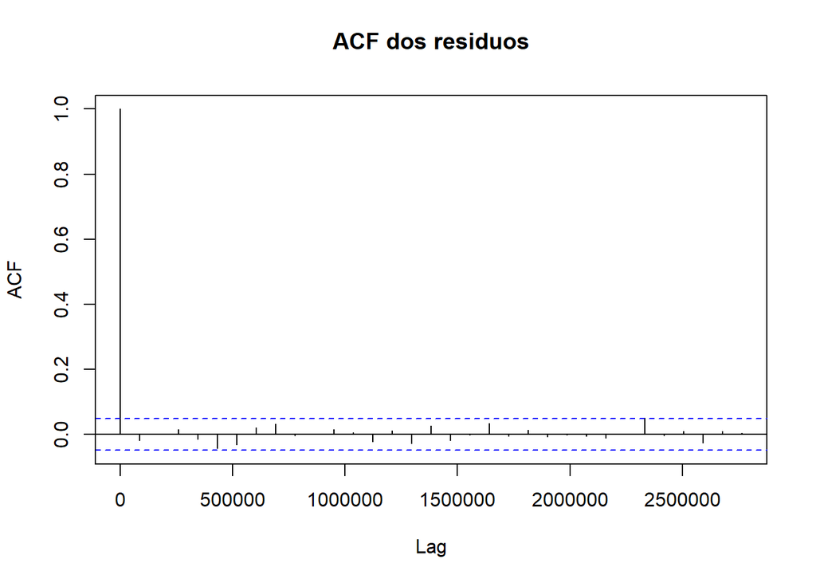

```r
residuals_best_model <- residuals(best_bic_model, standardize = TRUE)

acf(residuals_best_model, main = "ACF dos residuos")
```

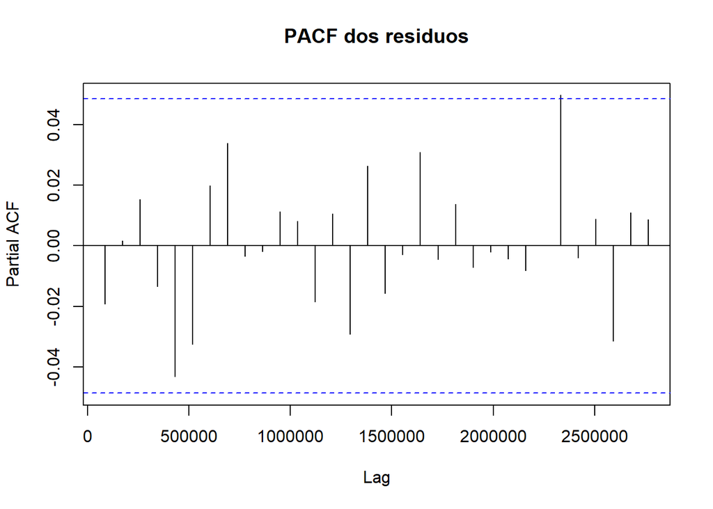

```r
pacf(residuals_best_model, main = "PACF dos residuos")
```

Tambem e realizado uma analisa utilizando o teste Ljung-Box sobre os residuos.

```r
print(Box.test(residuals_best_model, lag = 20, type = "Ljung-Box"))
```

```
##
##  Box-Ljung test
##
## data:  residuals_best_model
## X-squared = 14.437, df = 20, p-value = 0.8077
```

```r
print(Box.test(residuals_best_model^2, lag = 20, type = "Ljung-Box"))
```

```
##
##  Box-Ljung test
##
## data:  residuals_best_model^2
## X-squared = 0.94178, df = 20, p-value = 1
```

## **Sobre a volatilidade condicional**

Calculamos para os proximos 10 instantes de tempo, nesse caso 10 dias, a volatilidade condicional esperada do melhor modelo ajustado.

```r
vol_forecast <- ugarchforecast(best_bic_model, n.ahead = 10)

forecasted_sigma <- sigma(vol_forecast)

cat("Volatilidade condicional prevista para os proximos 10 instantes de tempo:\n")
```

```
## Volatilidade condicional prevista para os proximos 10 instantes de tempo:
```

```r
print(forecasted_sigma)
```

```
##      1974-06-13
## T+1  0.01966995
## T+2  0.01970628
## T+3  0.01974148
## T+4  0.01977557
## T+5  0.01980860
## T+6  0.01984060
## T+7  0.01987158
## T+8  0.01990160
## T+9  0.01993066
## T+10 0.01995881
```